# Confidence limits on what you predict

PCB 6455 / BSC 4933: Biometry | Lecture 21

Dr. Brian Maitner

## Today’s agenda

- Intervals on what the parameters **predict**: a value in one year, a change over time, a whole curve
- One recipe that works for all of them: **draw, compute, take the middle 95%**
- **Confidence** intervals versus **prediction** intervals

Type and run on a code block: type it into your script and run it. Code without the label is there to watch.

## The story so far

- A parameter’s interval: every value within **1.92** of the best NLL (Lecture 17)
- We can compare models, and fit them reliably (Lectures 18 to 20)
- **Today:** intervals on what the fitted model **predicts**

## Get set up

```r
library(bbmle)
library(biometrydata)

occ <- bobwhite_occupancy
counts <- bobwhite_counts

# occupancy against years since 1997, as in Lecture 17
m_occ <- mle2(n_occupied ~ dbinom(size = n_routes, prob = plogis(a + b * elapsed)),
              start = list(a = 2, b = -0.05), data = occ)
coef(m_occ)
confint(m_occ)
```

**Check:** $a$ = 2.02 and $b$ = -0.062, the decline of about 6% a year in the odds of occupancy from Lecture 17.

# The question is rarely a parameter

## What biologists actually ask

| The question | The answer is | Uses |
| --- | --- | --- |
| What fraction of routes had bobwhite in 2019? | $\text{logistic}(a + 22b)$ | $a$ and $b$ |
| How much did occupancy fall, 1997 to 2019? | $\text{logistic}(a) - \text{logistic}(a + 22b)$ | $a$ and $b$ |
| At what level of development are counts halved? | $\log(2) / -b$ | $b$ only |
| What does the whole decline look like? | $\text{logistic}(a + b \cdot \text{year})$, every year | $a$ and $b$ |

`confint()` gives intervals on $a$ and $b$. **None of these is $a$ or $b$.**

## Occupancy in 2019, give or take what?

The estimate: $\text{logistic}(a + 22b)$ = **66%** of routes.

A first idea: plug in the ends of the two intervals, every combination:

| $a$ | $b$ | Occupancy in 2019 |
| --- | --- | --- |
| 1.77 (low) | -0.08 (low) | 50% |
| 2.28 (high) | -0.08 (low) | 63% |
| 1.77 (low) | -0.044 (high) | 69% |
| 2.28 (high) | -0.044 (high) | 79% |

So somewhere from 50% to 79%? **Too wide, by a lot.**

## Why the corners are wrong

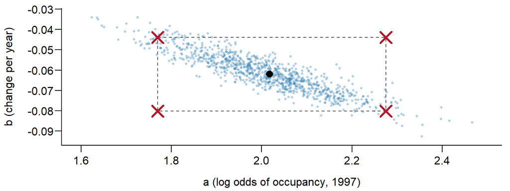

Each blue dot is a pair of values the data support. The dashed box is the two intervals. **Two of the corners sit far from every dot.**

The ends of two intervals are rarely plausible together. Here, a higher start goes with a steeper decline.

# One recipe: draw, compute, summarize

## The recipe

1. **Draw** 1,000 plausible sets of parameters from the fit, the blue dots
2. **Compute** the number you care about from each set
3. Take the **middle 95%** of those 1,000 numbers

It works for **any** number you can calculate from the parameters: a value, a difference, a ratio, a whole curve.

If you do not know the parameters exactly, try many plausible values and see how much the answer moves.

## Where plausible values come from

```r
vcov(m_occ)                 # the variance-covariance matrix
sqrt(diag(vcov(m_occ)))     # standard errors of a and b
cov2cor(vcov(m_occ))        # how strongly a and b move together
```

| Part of `vcov()` | Means |
| --- | --- |
| the diagonal | how uncertain each parameter is: its **standard error**, squared |
| off the diagonal | how the two move **together** |

**Check:** standard errors 0.129 and 0.0093, and a correlation of -0.89.

## Step 1: draw

```r
set.seed(21)
draws <- MASS::mvrnorm(1000, mu = coef(m_occ), Sigma = vcov(m_occ))
head(draws)
cor(draws)
```

`mvrnorm()` draws from a **multivariate normal**: centered on the estimates, with the spread and the tilt from `vcov()`.

**Check:** 1,000 rows, one plausible $(a, b)$ pair in each, and a correlation of about -0.89, the tilt from the picture.

## Steps 2 and 3: compute, summarize

```r
# occupancy in 2019 (22 years after 1997), once for each draw
occ19 <- plogis(draws[, "a"] + 22 * draws[, "b"])

hist(occ19)
quantile(occ19, c(0.025, 0.975))     # the middle 95%
```

**Check:** 61.5% to 70.8% of routes. Your last decimal may differ.

## Two surprises

| Method | Occupancy in 2019 |
| --- | --- |
| plug in the corners | 50% to 79% |
| **the recipe** | **61% to 71%** |

1. The recipe’s interval is about **a third as wide**
2. The real 2019 survey found bobwhite on **52 of 71 routes, 73%**: *outside* the interval

Is the model wrong? Hold that thought until the end of the lecture.

## Your turn: how much was lost?

**By how many percentage points did occupancy fall from 1997 to 2019?**

```r
# occupancy in 1997, for every draw, goes here (hint: elapsed is 0 in 1997)

# the drop, for every draw, goes here (you already have occ19)

# the middle 95% of the drop goes here
```

**Hint:** slide 13 computed occupancy in 2019 for every draw. Do the same for 1997, then subtract.

**Check:** a drop of about **22 points**, from 15 to 28.

## Two other ways, and when they work

| Method | Occupancy in 2019 | Works when |
| --- | --- | --- |
| **the recipe** | 61.5% to 70.8% | always; the bowl should be roughly round |
| **rewrite the model** so the number is a parameter | 61.0% to 70.4% | you can rewrite it, one number at a time |
| the **delta method**, from slopes and `vcov()` | 61.1% to 70.6% | as for $\pm$ 1.96 SE |

Rewriting, for this model: measure time from 2019 instead of 1997. Then $a$ **is** the log odds of occupancy in 2019, and `confint()` gives its profile interval.

# A band around the curve

## From one year to every year

A curve is the same calculation at **every year**. So the band is the recipe, run once per year:

- one **row** per draw (1,000)
- one **column** per year (23)
- the middle 95% of **each column**

## The band, step 1

```r
years <- occ$elapsed                 # the surveyed years, 0 to 22

# one row per draw, one column per year
curves <- matrix(NA, nrow = 1000, ncol = length(years))
for (i in 1:1000) {
  curves[i, ] <- plogis(draws[i, "a"] + draws[i, "b"] * years)
}

# the middle 95% of each column (the 2 means columns)
lower <- apply(curves, 2, quantile, 0.025)
upper <- apply(curves, 2, quantile, 0.975)
```

**Check:** `dim(curves)` is 1000 by 23. `lower[23]` and `upper[23]` are 2019’s interval from before.

## The band, step 2

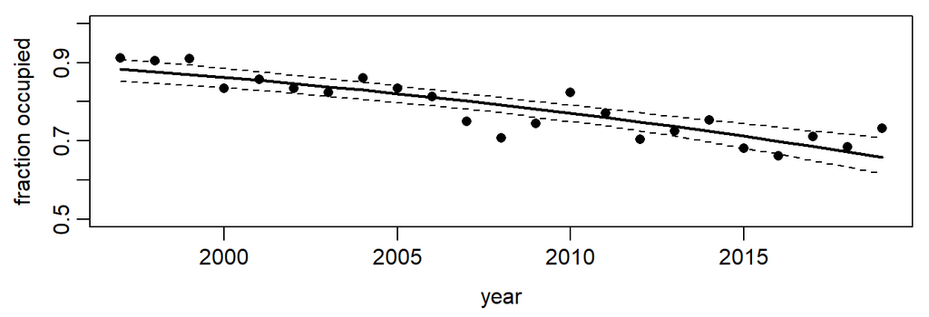

```r
obs <- occ$n_occupied / occ$n_routes
plot(occ$year, obs, pch = 16, ylim = c(0.5, 1),
     xlab = "year", ylab = "fraction of routes occupied")

lines(occ$year, plogis(coef(m_occ)["a"] + coef(m_occ)["b"] * years), lwd = 2)
lines(occ$year, lower, lty = 2)
lines(occ$year, upper, lty = 2)
```

## Why the band flares

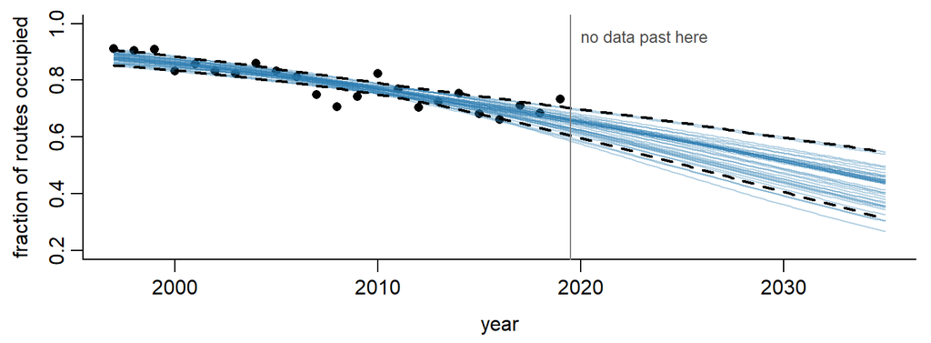

Forty of the 1,000 curves. They **pivot** near the middle of the data.

The band is narrowest where the data are, and keeps widening the further you predict beyond them.

## Is the model wrong?

Only **9 of the 23** years fall inside the band, 2019 among the misses.

The band answers: **where is the trend line?**

It does not answer: **where will a year’s survey land?** Each year’s survey scatters around the line: binomial scatter, from sampling 70-odd routes.

That needs a **prediction interval**.

# Where will the next survey land?

## Confidence or prediction?

| Interval | Includes | Answers |
| --- | --- | --- |
| **confidence** | uncertainty in the **parameters** | where is the average, the trend line? |
| **prediction** | the parameters **plus** the scatter of real data | where will one new observation land? |

To get a prediction interval: run the recipe, but in step 2 **simulate a survey** from each draw, instead of computing its average.

A confidence interval says where the average is. A prediction interval says where the next observation will land, so it is always wider.

## The prediction interval

```r
preds <- matrix(NA, nrow = 1000, ncol = length(years))
for (i in 1:1000) {
  p_i <- plogis(draws[i, "a"] + draws[i, "b"] * years)
  # one simulated survey per year, with that year's number of routes
  preds[i, ] <- rbinom(length(years), size = occ$n_routes, prob = p_i) / occ$n_routes
}
pred_lower <- apply(preds, 2, quantile, 0.025)
pred_upper <- apply(preds, 2, quantile, 0.975)

lines(occ$year, pred_lower, lty = 3, col = "red")
lines(occ$year, pred_upper, lty = 3, col = "red")
sum(obs >= pred_lower & obs <= pred_upper)
```

**Check:** about **23 of 23** years inside the red lines.

## Both, together

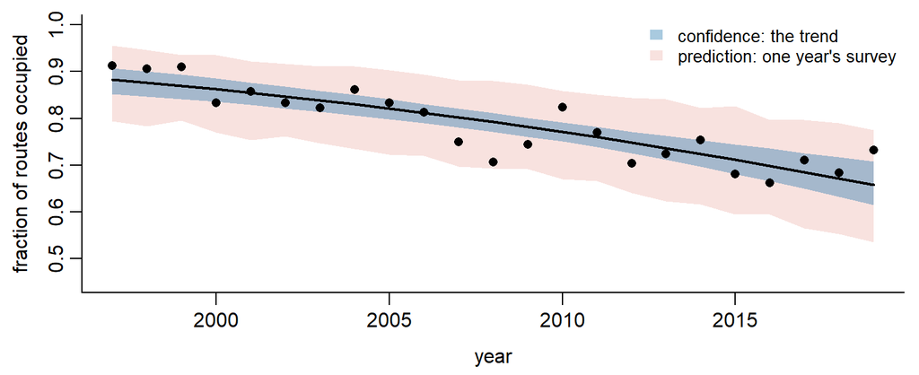

The prediction band is about **4 times as wide**. Almost all of that width is the scatter of real surveys.

## Vote: confidence or prediction?

Hands up for **confidence**, then for **prediction**:

|  | The question |  |
| --- | --- | --- |
| 1 | Has bobwhite occupancy declined since 1997? | **confidence** |
| 2 | Is the warbler you just caught unusually light? | **prediction** |
| 3 | How much does protection raise reef fish biomass, on average? | **confidence** |
| 4 | Seedlings to plant at a restoration site so 100 survive | **prediction** |
| 5 | Does a pesticide lower bumblebee colony survival? | **confidence** |
| 6 | Will the next reef you survey, at 15 m, have over 30 species? | **prediction** |

Ask: is the question about the average, or about one particular case? The average needs a confidence interval. One case needs a prediction interval.

# Your turn: bobwhite and development

## Get set up: counts and development

```r
# bobwhite counted on a route, against the fraction of the route developed
m_nb <- mle2(count ~ dnbinom(mu = exp(log_mu0 + b * frac_built), size = exp(log_k)),
             start = list(log_mu0 = 2.5, b = -3, log_k = 0), data = counts)
coef(m_nb)

set.seed(22)
draws_nb <- MASS::mvrnorm(1000, mu = coef(m_nb), Sigma = vcov(m_nb))
```

**Check:** $b$ = -3.23.

Why `log_mu0` and `log_k`? Draws from a normal can be **negative**. On the log scale, every draw is a legal value.

## One parameter: transform the ends

The **halving point**: how developed a route can be before its expected count halves. It uses $b$ **only**.

```r
log(2) / -coef(m_nb)["b"]                  # the halving point
log(2) / -confint(m_nb)["b", ]        # its interval: transform the ends
```

When a number is calculated from just one parameter, put each end of that parameter’s interval through the same calculation: the two answers are the number’s interval. With two or more parameters, that runs into the corners problem from slide 8, so use the recipe.

## Your turn: the band for development

```r
built <- seq(0, 0.5, by = 0.01)     # 0% to 50% developed

counts_curves <- matrix(NA, nrow = 1000, ncol = length(built))
for (i in 1:1000) {
  # the expected count at every value of built, for draw i, goes here
}

# the lower and upper ends of the band go here

plot(counts$frac_built, counts$count, col = "grey", ylim = c(0, 40),
     xlab = "fraction developed", ylab = "bobwhite counted")
# the fitted curve and the two ends of the band go here
```

**Hint:** slides 19 and 20 built the occupancy band. Same steps, with the draws from slide 29 and `exp(log_mu0 + b * built)` in place of `plogis(a + b * years)`.

**Check:** at 20% developed (`built[21]`), the average route has 5.8 to 7.0 bobwhite.

## Your turn: one route

A landowner’s route is **20% developed**. How many bobwhite will its survey find?

```r
mu_20 <- exp(draws_nb[, "log_mu0"] + draws_nb[, "b"] * 0.2)
quantile(mu_20, c(0.025, 0.975))          # the average route at 20%

# one simulated count per draw goes here (hint: rnbinom(), with mu = mu_20;
# for size, use the log_k column of draws_nb, the way mu_20 used log_mu0)

# the middle 95% of those counts goes here
```

**Check:** the average route, 5.8 to 7.0 birds. One route, **0 to 21**.

# Wrapping up

## Which tool, when

| You want an interval on | Use |
| --- | --- |
| one parameter | `confint()` (Lecture 17) |
| a number built from **one** parameter | `confint()`, then transform the ends |
| a number built from **several** | the recipe: draw, compute, middle 95% |
| a whole curve | the recipe, at every $x$ |
| where **new data** will land | the recipe, plus simulating the scatter |

Coming up: `lm()` and `glm()` have **shortcuts** for some of these (Lectures 23 and 24). The recipe works for any model, including the ones they cannot fit.

## Before next class

Skim Bolker **chapter 8**

**Assignment 3** is due **Friday, November 6**

Next time: **likelihood examples**, worked through in class